title: Ensembling Multiple Classification Models output: rmarkdown::github_document —

# Trying Out and Ensembling Different Classification Models

**This is the second complete notebook that I am creating. [Here’s a link to the first](https://github.com/elijahrona/Elijah-Rona-ML-Journey/blob/master/do-you-have-malaria-or-covid-19.ipynb) where I worked with Covid-19, Malaria, and Negative patients.**

**The purpose of this notebook is to improve my Recipes(), Workflow(), and Ensembling (Stacks()) skills.**

# Importing Libraries

```r
library(tidyverse)
library(tidymodels)
```

# Dataset

```r
mine <- read.csv("C:/Users/Octopus/Desktop/in-vehicle-coupon-recommendation.csv", stringsAsFactors=TRUE)
head(mine)
```

```
##       destination passanger weather temperature time                coupon
## 1 No Urgent Place     Alone   Sunny          55  2PM       Restaurant(<20)
## 2 No Urgent Place Friend(s)   Sunny          80 10AM          Coffee House
## 3 No Urgent Place Friend(s)   Sunny          80 10AM Carry out & Take away
## 4 No Urgent Place Friend(s)   Sunny          80  2PM          Coffee House
## 5 No Urgent Place Friend(s)   Sunny          80  2PM          Coffee House
## 6 No Urgent Place Friend(s)   Sunny          80  6PM       Restaurant(<20)
##   expiration gender age     maritalStatus has_children                education
## 1         1d Female  21 Unmarried partner            1 Some college - no degree
## 2         2h Female  21 Unmarried partner            1 Some college - no degree
## 3         2h Female  21 Unmarried partner            1 Some college - no degree
## 4         2h Female  21 Unmarried partner            1 Some college - no degree
## 5         1d Female  21 Unmarried partner            1 Some college - no degree
## 6         2h Female  21 Unmarried partner            1 Some college - no degree
##   occupation          income   Bar CoffeeHouse RestaurantLessThan20
```

[output cut: 20 more lines]

Let’s have a glimpse of what our dataset looks like.

```r
skimmed <- skimr::skim(mine)
skimmed <- skimmed[, c(1:5, 9:11, 13, 15)]
skimmed
```

Data summary

| Name | mine |
| --- | --- |
| Number of rows | 12684 |
| Number of columns | 23 |
| _______________________ |  |
| Column type frequency: |  |
| factor | 16 |
| numeric | 7 |
| ________________________ |  |
| Group variables | None |

**Variable type: factor**

| skim_variable | n_missing | complete_rate | ordered |
| --- | --- | --- | --- |
| destination | 0 | 1 | FALSE |
| passanger | 0 | 1 | FALSE |
| weather | 0 | 1 | FALSE |
| time | 0 | 1 | FALSE |
| coupon | 0 | 1 | FALSE |
| expiration | 0 | 1 | FALSE |
| gender | 0 | 1 | FALSE |
| age | 0 | 1 | FALSE |
| maritalStatus | 0 | 1 | FALSE |
| education | 0 | 1 | FALSE |
| occupation | 0 | 1 | FALSE |
| income | 0 | 1 | FALSE |
| Bar | 0 | 1 | FALSE |
| CoffeeHouse | 0 | 1 | FALSE |
| RestaurantLessThan20 | 0 | 1 | FALSE |
| Restaurant20To50 | 0 | 1 | FALSE |

**Variable type: numeric**

| skim_variable | n_missing | complete_rate | sd | p0 | p25 | p75 | hist |
| --- | --- | --- | --- | --- | --- | --- | --- |
| temperature | 0 | 1 | 19.15 | 30 | 55 | 80 | ▃▁▅▁▇ |
| has_children | 0 | 1 | 0.49 | 0 | 0 | 1 | ▇▁▁▁▆ |
| toCoupon_GEQ15min | 0 | 1 | 0.50 | 0 | 0 | 1 | ▆▁▁▁▇ |
| toCoupon_GEQ25min | 0 | 1 | 0.32 | 0 | 0 | 0 | ▇▁▁▁▁ |
| direction_same | 0 | 1 | 0.41 | 0 | 0 | 0 | ▇▁▁▁▂ |
| direction_opp | 0 | 1 | 0.41 | 0 | 1 | 1 | ▂▁▁▁▇ |
| Y | 0 | 1 | 0.50 | 0 | 0 | 1 | ▆▁▁▁▇ |

The response variable, Y appears to be numeric. It should be a factor, so we should convert it with factor(). Also, it seems that the temperature column has only three numbers, so we should also treat it as a factor.

```r
mine <- mine %>%
mutate(temperature = factor(temperature),
      Y = factor(Y))
```

```r
is.factor(mine$Y)
```

```
## [1] TRUE
```

# Splitting the Dataset

```r
ames_split  <- initial_split(mine,
                             strata = Y,
                             breaks = 4)
ames_train  <- training(ames_split)
ames_test   <- testing(ames_split)
```

# Creating the Recipe

```r
train_rec <- recipe(Y ~ ., data = ames_train) %>%
step_dummy(all_nominal_predictors())
```

Let’s check if the recipe works. The data below is what it looks like after processing it with recipe. This is the way our models will read it

```r
train_rec %>%
prep(training = ames_train, retain = TRUE) %>%
juice() %>%
head()
```

```
## * income_X.12500....24999 -> income_X.12500.
## * income_X.25000....37499 -> income_X.25000.
## * income_X.37500....49999 -> income_X.37500.
## * income_X.50000....62499 -> income_X.50000.
## * income_X.62500....74999 -> income_X.62500.
## * ...
```

```
## # A tibble: 6 x 93
##   has_children toCoupon_GEQ15min toCoupon_GEQ25min direction_same direction_opp
##          <int>             <int>             <int>          <int>         <int>
## 1            1                 0                 0              0             1
## 2            1                 1                 0              0             1
## 3            1                 1                 0              0             1
## 4            1                 1                 0              0             1
## 5            1                 0                 0              0             1
## 6            1                 1                 1              0             1
## # ... with 88 more variables: Y <fct>, destination_No.Urgent.Place <dbl>,
## #   destination_Work <dbl>, passanger_Friend.s. <dbl>, passanger_Kid.s. <dbl>,
## #   passanger_Partner <dbl>, weather_Snowy <dbl>, weather_Sunny <dbl>,
## #   temperature_X55 <dbl>, temperature_X80 <dbl>, time_X10PM <dbl>,
## #   time_X2PM <dbl>, time_X6PM <dbl>, time_X7AM <dbl>,
## #   coupon_Carry.out...Take.away <dbl>, coupon_Coffee.House <dbl>,
## #   coupon_Restaurant..20. <dbl>, coupon_Restaurant.20.50. <dbl>,
## #   expiration_X2h <dbl>, gender_Male <dbl>, age_X26 <dbl>, age_X31 <dbl>,
## #   age_X36 <dbl>, age_X41 <dbl>, age_X46 <dbl>, age_X50plus <dbl>,
## #   age_below21 <dbl>, maritalStatus_Married.partner <dbl>,
## #   maritalStatus_Single <dbl>, maritalStatus_Unmarried.partner <dbl>,
## #   maritalStatus_Widowed <dbl>, education_Bachelors.degree <dbl>,
## #   education_Graduate.degree..Masters.or.Doctorate. <dbl>,
## #   education_High.School.Graduate <dbl>,
## #   education_Some.college...no.degree <dbl>, education_Some.High.School <dbl>,
## #   occupation_Arts.Design.Entertainment.Sports...Media <dbl>,
## #   occupation_Building...Grounds.Cleaning...Maintenance <dbl>,
## #   occupation_Business...Financial <dbl>,
## #   occupation_Community...Social.Services <dbl>,
## #   occupation_Computer...Mathematical <dbl>,
## #   occupation_Construction...Extraction <dbl>,
## #   occupation_Education.Training.Library <dbl>,
## #   occupation_Farming.Fishing...Forestry <dbl>,
## #   occupation_Food.Preparation...Serving.Related <dbl>,
## #   occupation_Healthcare.Practitioners...Technical <dbl>,
## #   occupation_Healthcare.Support <dbl>,
## #   occupation_Installation.Maintenance...Repair <dbl>, occupation_Legal <dbl>,
## #   occupation_Life.Physical.Social.Science <dbl>, occupation_Management <dbl>,
## #   occupation_Office...Administrative.Support <dbl>,
## #   occupation_Personal.Care...Service <dbl>,
## #   occupation_Production.Occupations <dbl>,
## #   occupation_Protective.Service <dbl>, occupation_Retired <dbl>,
## #   occupation_Sales...Related <dbl>, occupation_Student <dbl>,
## #   occupation_Transportation...Material.Moving <dbl>,
## #   occupation_Unemployed <dbl>, income_X.12500. <dbl>, income_X.25000. <dbl>,
## #   income_X.37500. <dbl>, income_X.50000. <dbl>, income_X.62500. <dbl>,
## #   income_X.75000. <dbl>, income_X.87500. <dbl>,
## #   income_Less.than..12500 <dbl>, Bar_X1.3 <dbl>, Bar_X4.8 <dbl>,
## #   Bar_gt8 <dbl>, Bar_less1 <dbl>, Bar_never <dbl>, CoffeeHouse_X1.3 <dbl>,
## #   CoffeeHouse_X4.8 <dbl>, CoffeeHouse_gt8 <dbl>, CoffeeHouse_less1 <dbl>,
## #   CoffeeHouse_never <dbl>, RestaurantLessThan20_X1.3 <dbl>,
## #   RestaurantLessThan20_X4.8 <dbl>, RestaurantLessThan20_gt8 <dbl>,
## #   RestaurantLessThan20_less1 <dbl>, RestaurantLessThan20_never <dbl>,
## #   Restaurant20To50_X1.3 <dbl>, Restaurant20To50_X4.8 <dbl>,
## #   Restaurant20To50_gt8 <dbl>, Restaurant20To50_less1 <dbl>,
## #   Restaurant20To50_never <dbl>
```

# Specifying Our Models

We shall be working with four models; Logistic Regression, MARS, Random Forest (named treebag), and XGBOOST

```r
log_spec <- logistic_reg(penalty = 10) %>%
  set_engine(engine = "glm") %>%
  set_mode("classification")

mars_spec <- mars() %>%
  set_mode("classification") %>%
  set_engine("earth")

treebag_spec <- rand_forest() %>%
  set_engine("ranger") %>%
  set_mode("classification")

xgboost_spec <- boost_tree() %>%
  set_mode("classification") %>%
  set_engine("xgboost")
```

# Adding Our Models and Recipe Into Various Workflows

A workflow is created for each model, but with the same recipe

```r
wf_log <- workflow() %>%
add_recipe(train_rec) %>%
add_model(log_spec)

wf_mars <- workflow() %>%
add_recipe(train_rec) %>%
add_model(mars_spec)

wf_treebag <- workflow() %>%
add_recipe(train_rec) %>%
add_model(treebag_spec)

wf_xgboost <- workflow() %>%
add_recipe(train_rec) %>%
add_model(xgboost_spec)
```

# Building Our Logistic Model

First of all, let us start with fitting the train data

```r
train_fit_log <-
  wf_log %>%
  fit(data = ames_train)
```

```
## * income_X.12500....24999 -> income_X.12500.
## * income_X.25000....37499 -> income_X.25000.
## * income_X.37500....49999 -> income_X.37500.
## * income_X.50000....62499 -> income_X.50000.
## * income_X.62500....74999 -> income_X.62500.
## * ...
```

Now we move to predicting the test data. Note that the data was also processed with the recipe

```r
pred_log <- augment(train_fit_log, ames_test)
```

```
## * income_X.12500....24999 -> income_X.12500.
## * income_X.25000....37499 -> income_X.25000.
## * income_X.37500....49999 -> income_X.37500.
## * income_X.50000....62499 -> income_X.50000.
## * income_X.62500....74999 -> income_X.62500.
## * ...
```

What is the accuracy of our model prediction?

```r
LOG_Accuracy <- pred_log %>%
  accuracy(truth = Y, .pred_class)

LOG_Accuracy[[1,3]]
```

```
## [1] 0.6800126
```

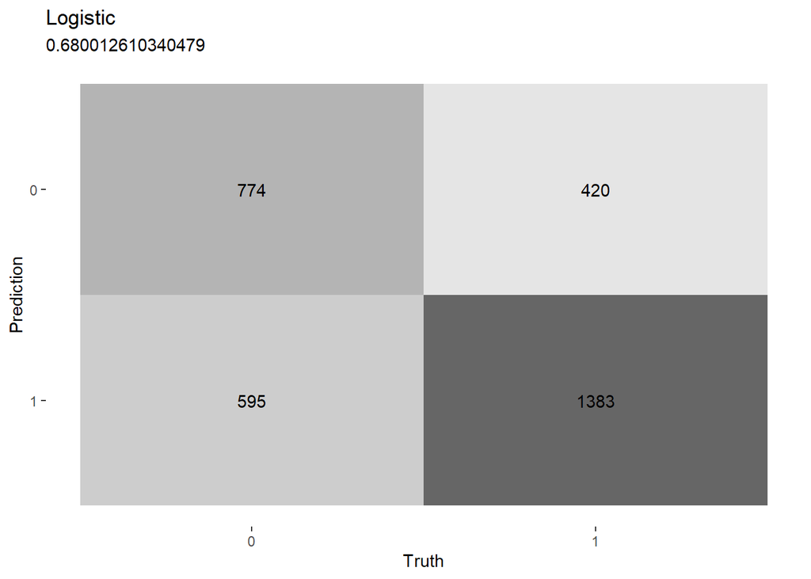

```r
p1 <- conf_mat(pred_log, truth = Y, estimate = .pred_class) %>%
  autoplot(type = "heatmap") +
  labs(title = "Logistic",
       subtitle = LOG_Accuracy[[1,3]])

p1
```

The Logistic model is not so bad. Let’s see if there are better models.

# Building Our MARS Model

```r
train_fit_mars <-
  wf_mars %>%
  fit(data = ames_train)
```

```
## * income_X.12500....24999 -> income_X.12500.
## * income_X.25000....37499 -> income_X.25000.
## * income_X.37500....49999 -> income_X.37500.
## * income_X.50000....62499 -> income_X.50000.
## * income_X.62500....74999 -> income_X.62500.
## * ...
```

```r
pred_mars <- augment(train_fit_mars, ames_test)
```

```
## * income_X.12500....24999 -> income_X.12500.
## * income_X.25000....37499 -> income_X.25000.
## * income_X.37500....49999 -> income_X.37500.
## * income_X.50000....62499 -> income_X.50000.
## * income_X.62500....74999 -> income_X.62500.
## * ...
```

```r
MARS_Accuracy <- pred_mars %>%
  accuracy(truth = Y, .pred_class)

MARS_Accuracy[[1,3]]
```

```
## [1] 0.6721311
```

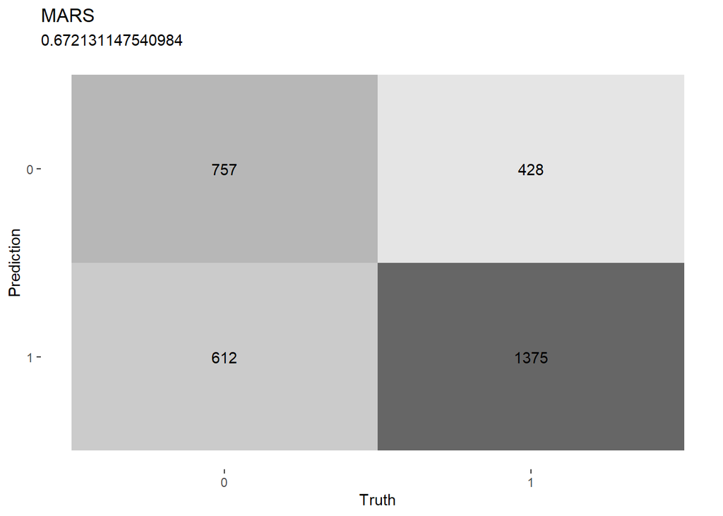

```r
p2 <- conf_mat(pred_mars, truth = Y, estimate = .pred_class) %>%
  autoplot(type = "heatmap") +
  labs(title = "MARS",
       subtitle = MARS_Accuracy[[1,3]])

p2
```

# Building Our Random Forest Model

```r
train_fit_treebag <-
  wf_treebag %>%
  fit(data = ames_train)
```

```
## * income_X.12500....24999 -> income_X.12500.
## * income_X.25000....37499 -> income_X.25000.
## * income_X.37500....49999 -> income_X.37500.
## * income_X.50000....62499 -> income_X.50000.
## * income_X.62500....74999 -> income_X.62500.
## * ...
```

```r
pred_treebag <- augment(train_fit_treebag, ames_test)
```

```
## * income_X.12500....24999 -> income_X.12500.
## * income_X.25000....37499 -> income_X.25000.
## * income_X.37500....49999 -> income_X.37500.
## * income_X.50000....62499 -> income_X.50000.
## * income_X.62500....74999 -> income_X.62500.
## * ...
```

```r
TREEBAG_Accuracy <- pred_treebag %>%
  accuracy(truth = Y, .pred_class)

TREEBAG_Accuracy[[1,3]]
```

```
## [1] 0.7559899
```

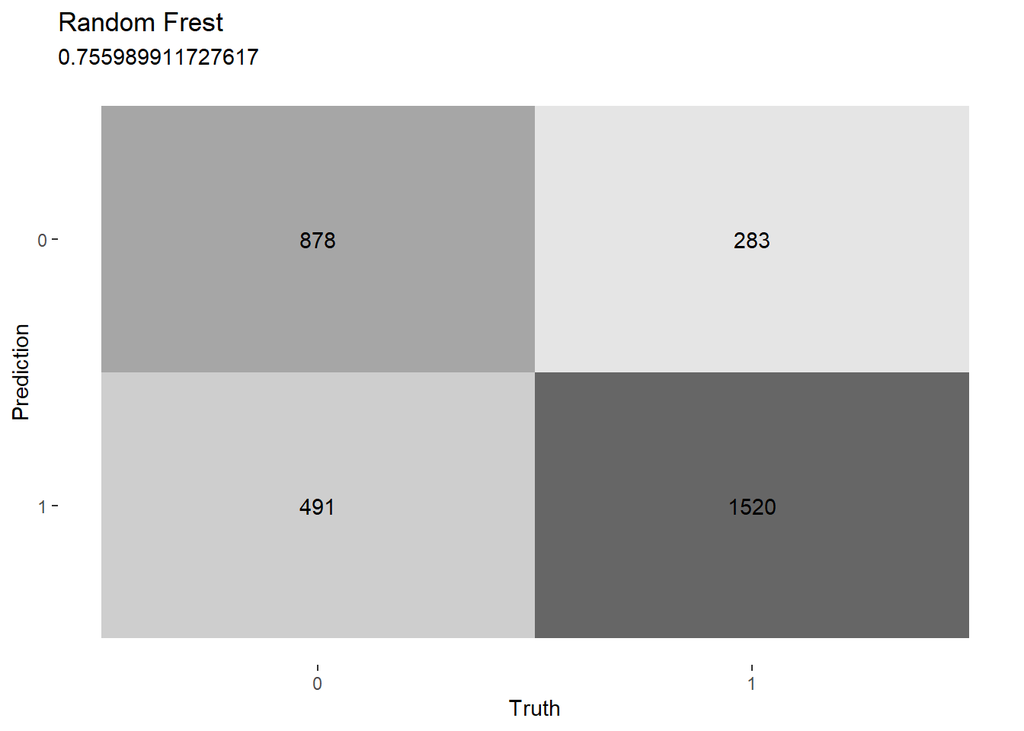

```r
p3 <- conf_mat(pred_treebag, truth = Y, estimate = .pred_class) %>%
  autoplot(type = "heatmap") +
  labs(title = "Random Frest",
       subtitle = TREEBAG_Accuracy[[1,3]])

p3
```

# Building Our XGBOOST Model

```r
train_fit_xgboost <-
  wf_xgboost %>%
  fit(data = ames_train)
```

```
## * income_X.12500....24999 -> income_X.12500.
## * income_X.25000....37499 -> income_X.25000.
## * income_X.37500....49999 -> income_X.37500.
## * income_X.50000....62499 -> income_X.50000.
## * income_X.62500....74999 -> income_X.62500.
## * ...
```

```
## [03:43:10] WARNING: amalgamation/../src/learner.cc:1095: Starting in XGBoost 1.3.0, the default evaluation metric used with the objective 'binary:logistic' was changed from 'error' to 'logloss'. Explicitly set eval_metric if you'd like to restore the old behavior.
```

```r
pred_xgboost <- augment(train_fit_xgboost, ames_test)
```

```
## * income_X.12500....24999 -> income_X.12500.
## * income_X.25000....37499 -> income_X.25000.
## * income_X.37500....49999 -> income_X.37500.
## * income_X.50000....62499 -> income_X.50000.
## * income_X.62500....74999 -> income_X.62500.
## * ...
```

```r
XGBOOST_Accuracy <- pred_xgboost %>%
  accuracy(truth = Y, .pred_class)

XGBOOST_Accuracy[[1,3]]
```

```
## [1] 0.7279319
```

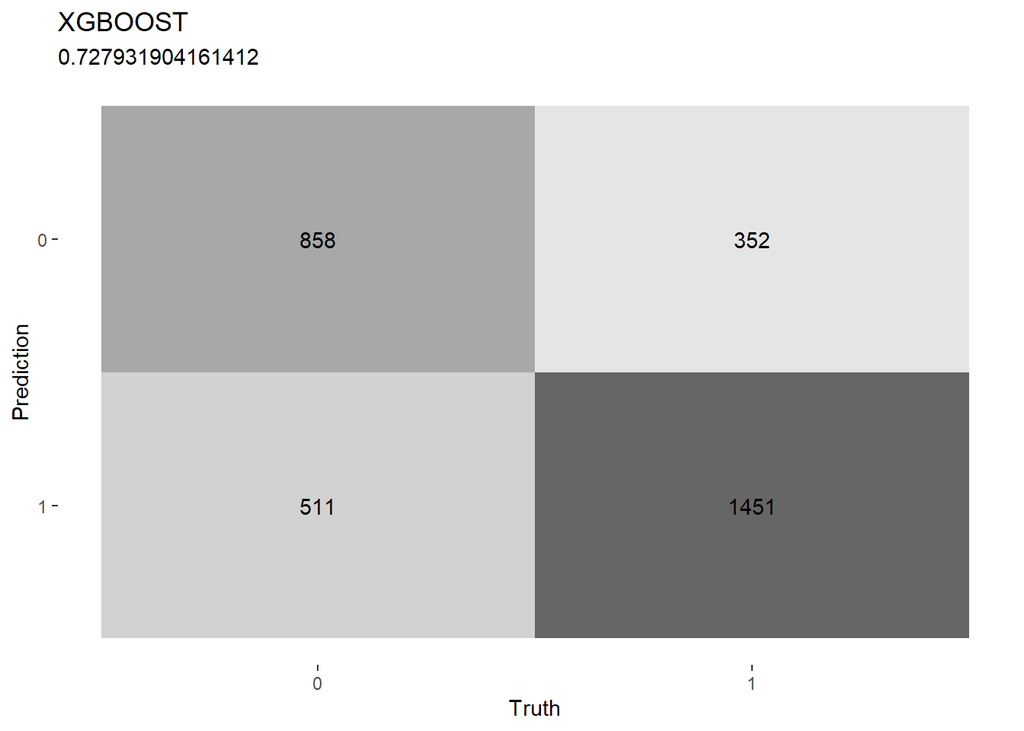

```r
p4 <- conf_mat(pred_xgboost, truth = Y, estimate = .pred_class) %>%
  autoplot(type = "heatmap") +
  labs(title = "XGBOOST",
       subtitle = XGBOOST_Accuracy[[1,3]])

p4
```

# Confusion Matrix for Every Model

We can see that the Random Forest model is best while the MARS is the worst.

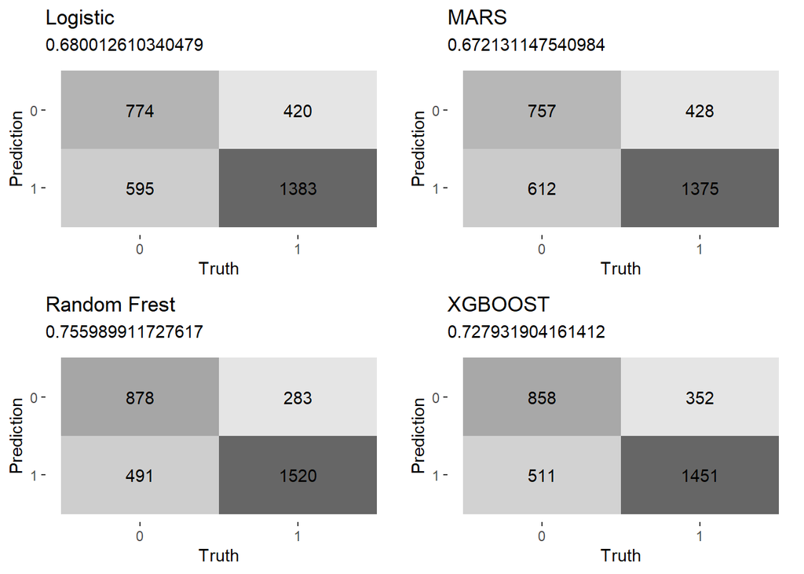

```r
ggpubr::ggarrange(p1,p2,p3,p4,
                   ncol = 2,
                   nrow = 2)
```

# Ensembling Our Models

Let us start by creating our cross validation folds

```r
ctrl_grid <- stacks::control_stack_grid()
ctrl_res <- stacks::control_stack_resamples()

folds <- rsample::vfold_cv(ames_train, v = 5)

metric <- metric_set(accuracy, roc_auc)
```

# Preparing the MARS Model for Ensembling

```r
mars_res <-
  fit_resamples(
    wf_mars, #workflow
    resamples = folds, #cvfold
    metrics = metric,
    control = ctrl_res
  )
```

[output not shown]

# Preparing the Random Forest Model for Ensembling

```r
treebag_res <-
  fit_resamples(
    wf_treebag, #workflow
    resamples = folds, #cvfold
    metrics = metric,
    control = ctrl_res
  )
```

[output not shown]

# Preparing the XGBOOST Model for Ensembling

```r
xgboost_res <-
  fit_resamples(
    wf_xgboost, #workflow
    resamples = folds, #cvfold
    metrics = metric,
    control = ctrl_res
  )
```

[output not shown]

# Preparing the Logistic Model for Ensembling

```r
log_res <-
  fit_resamples(
    wf_log, #workflow
    resamples = folds, #cvfold
    metrics = metric,
    control = ctrl_res
  )
```

[output not shown]

```
## ! Fold1: preprocessor 1/1, model 1/1 (predictions): prediction from a rank-defici...
```

[output not shown]

```
## ! Fold2: preprocessor 1/1, model 1/1 (predictions): prediction from a rank-defici...
```

[output not shown]

```
## ! Fold3: preprocessor 1/1, model 1/1 (predictions): prediction from a rank-defici...
```

[output not shown]

```
## ! Fold4: preprocessor 1/1, model 1/1 (predictions): prediction from a rank-defici...
```

[output not shown]

```
## ! Fold5: preprocessor 1/1, model 1/1 (predictions): prediction from a rank-defici...
```

# Adding Every Model to Our Stack

```r
library(stacks)
model_data_st <-  stacks() %>%
  add_candidates(log_res) %>%
  add_candidates(treebag_res) %>%
  add_candidates(xgboost_res) %>%
  add_candidates(mars_res)

head(model_data_st)
```

```
## # A data stack with 4 model definitions and 4 candidate members:
## #   log_res: 1 model configuration
## #   treebag_res: 1 model configuration
## #   xgboost_res: 1 model configuration
## #   mars_res: 1 model configuration
## # Outcome: Y (factor)
```

There are several class probabilities. To know the combined model prediction, we will use the blend_predictions() function.

```r
fitted_model_st <-
  model_data_st %>%
  blend_predictions()
```

Let us expore our ensambled model to know how the members are performing.

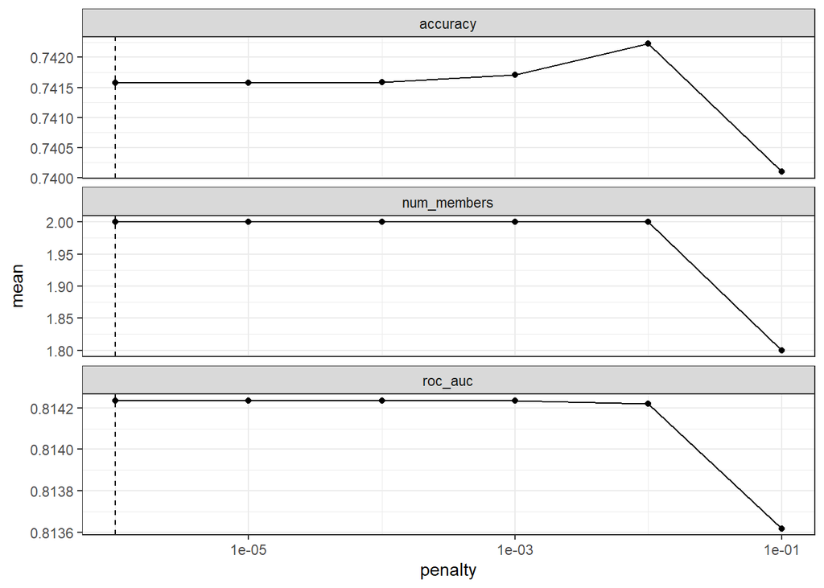

```r
theme_set(theme_bw())
autoplot(fitted_model_st)
```

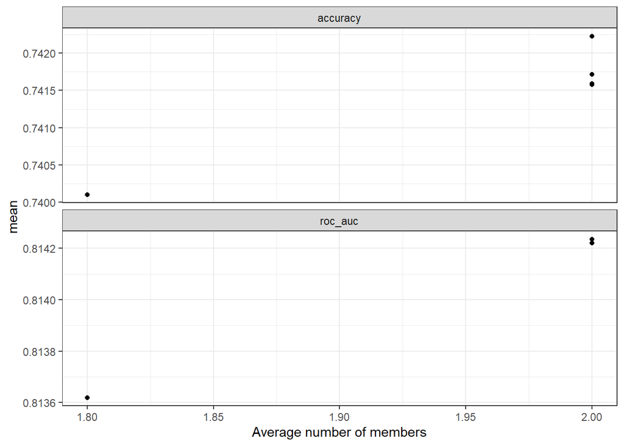

```r
autoplot(fitted_model_st, type = "members")
```

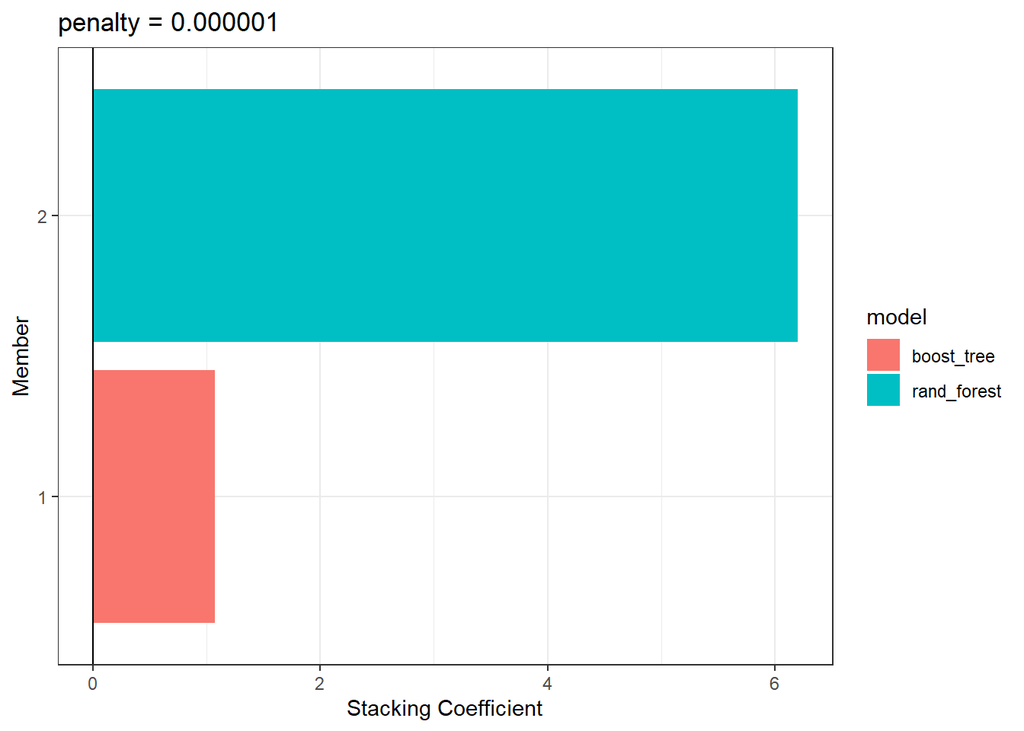

```r
autoplot(fitted_model_st, type = "weights")
```

```r
fitted_model_st
```

```
## -- A stacked ensemble model -------------------------------------
```

```
##
## Out of 4 possible candidate members, the ensemble retained 2.
## Penalty: 1e-06.
## Mixture: 1.
```

```
##
## The 2 highest weighted member classes are:
```

```
## # A tibble: 2 x 3
##   member                  type        weight
##   <chr>                   <chr>        <dbl>
## 1 .pred_1_treebag_res_1_1 rand_forest   6.20
## 2 .pred_1_xgboost_res_1_1 boost_tree    1.08
```

```
##
## Members have not yet been fitted with `fit_members()`.
```

The final model retained just two of our models; Random Forest and XGBOOST. Let us combine these models to predict our test data.

```r
fitted_model_st <-
  fitted_model_st %>%
  fit_members()
```

```
## * income_X.12500....24999 -> income_X.12500.
## * income_X.25000....37499 -> income_X.25000.
## * income_X.37500....49999 -> income_X.37500.
## * income_X.50000....62499 -> income_X.50000.
## * income_X.62500....74999 -> income_X.62500.
## * ...
## * income_X.12500....24999 -> income_X.12500.
## * income_X.25000....37499 -> income_X.25000.
## * income_X.37500....49999 -> income_X.37500.
## * income_X.50000....62499 -> income_X.50000.
## * income_X.62500....74999 -> income_X.62500.
## * ...
```

```
## [03:47:55] WARNING: amalgamation/../src/learner.cc:1095: Starting in XGBoost 1.3.0, the default evaluation metric used with the objective 'binary:logistic' was changed from 'error' to 'logloss'. Explicitly set eval_metric if you'd like to restore the old behavior.
```

```r
test_predict_data <-
  ames_test %>%
  bind_cols(predict(fitted_model_st, .))
```

```
## * income_X.12500....24999 -> income_X.12500.
## * income_X.25000....37499 -> income_X.25000.
## * income_X.37500....49999 -> income_X.37500.
## * income_X.50000....62499 -> income_X.50000.
## * income_X.62500....74999 -> income_X.62500.
## * ...
## * income_X.12500....24999 -> income_X.12500.
## * income_X.25000....37499 -> income_X.25000.
## * income_X.37500....49999 -> income_X.37500.
## * income_X.50000....62499 -> income_X.50000.
## * income_X.62500....74999 -> income_X.62500.
## * ...
```

# Prediting the test data

```r
member_preds <-
  test_predict_data %>%
  select(Y) %>%
  bind_cols(predict(fitted_model_st, ames_test, members = TRUE))
```

```
## * income_X.12500....24999 -> income_X.12500.
## * income_X.25000....37499 -> income_X.25000.
## * income_X.37500....49999 -> income_X.37500.
## * income_X.50000....62499 -> income_X.50000.
## * income_X.62500....74999 -> income_X.62500.
## * ...
## * income_X.12500....24999 -> income_X.12500.
## * income_X.25000....37499 -> income_X.25000.
## * income_X.37500....49999 -> income_X.37500.
## * income_X.50000....62499 -> income_X.50000.
## * income_X.62500....74999 -> income_X.62500.
## * ...
```

```r
head(member_preds)
```

```
##   Y .pred_class .pred_class_treebag_res_1_1 .pred_class_xgboost_res_1_1
## 1 0           1                           1                           1
## 2 0           0                           0                           1
## 3 0           0                           0                           1
## 4 0           0                           0                           1
## 5 1           1                           1                           1
## 6 0           0                           0                           0
```

Let us compare the accuracy of the combined model with that of the other member models

```r
map_dfr(member_preds, accuracy, truth = Y, data = member_preds) %>%
  mutate(member = colnames(member_preds))
```

```
## # A tibble: 4 x 4
##   .metric  .estimator .estimate member
##   <chr>    <chr>          <dbl> <chr>
## 1 accuracy binary         1     Y
## 2 accuracy binary         0.760 .pred_class
## 3 accuracy binary         0.759 .pred_class_treebag_res_1_1
## 4 accuracy binary         0.728 .pred_class_xgboost_res_1_1
```

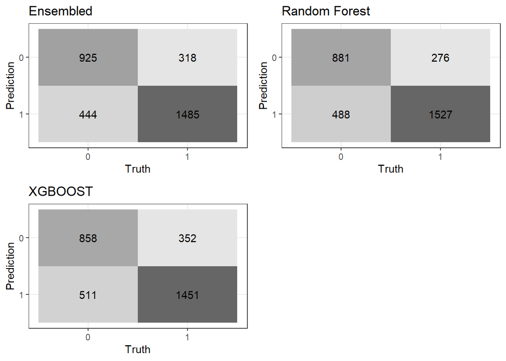

```r
p1 <- conf_mat(member_preds, truth = Y, estimate = .pred_class) %>%
  autoplot(type = "heatmap") +
  labs(title = "Ensembled")

p2 <- conf_mat(member_preds, truth = Y, estimate = .pred_class_treebag_res_1_1) %>%
  autoplot(type = "heatmap") +
  labs(title = "Random Forest")

p3 <- conf_mat(member_preds, truth = Y, estimate = .pred_class_xgboost_res_1_1) %>%
  autoplot(type = "heatmap") +
  labs(title = "XGBOOST")

ggpubr::ggarrange(p1,p2,p3,
          ncol = 2,
          nrow = 2)
```